# Project2_ChenD_ZhangM_LiR

## Valuation Project 2: Finite Difference

### Name: Renjun Li, Meichen Zhang, Danni Chen

### NetID : renjunl2, meichen6, dannic3

## 1. Financial Instrument Description

Amazon Auto-Callable Contingent Interest Notes(Choice #1)

#### Key features:

1. Contingent coupon payments determined on the 5 review dates.
2. Autocall feature determined on the 5 review dates.
3. Continuous Barrier feature.

## 2. Choice of Model

- We used Crank-Nicolson finite differece method with LU algorithm to value this note.
- Reason: Compared to the explicit method, CN method is more stable, more accurate, and requires fewer restrictions while choosing time steps. It has faster convergence than explicit method. Although it is more complex to program, we are trying our best to use this method properly.

## 3. CN Model Construction(LU decomposition) and Data Inputs

### Given the basic structure of the Note, we obtained the following data from Bloomberg with Professor Widdicks’s help:

#### 1. Interest rate: r(0, T) = 0.005131

- It is based on shorting American put at moneyness 70% in 458 days, whose underlying asset is AMZN Equity at price 1785.00 at trading date Mar 13, 2020.

#### 3. Dividends: div=0

- As the note information shows that there is no dividends here.

#### 4. Initial Stock Price: S0=1785.00

#### 5. Trigger Event Threshold: B=0.7S0

#### 6. Upper Boundary Condition (UBC)= 3S0

- we set the Upper Boundary Condition (UBC) to S=3S0, which seems a reasonable boundary.

#### 7. Lower Boundary Condition (LBC)

- Lower Boundary Condition in the non-trigger grid comes from the trigger grid when S = 0.7S0 (Barrier level). If we use the part of the trigger grid where S<=0.7S0(Barrier) to replace the corresponding part of the non-trigger grid, the LBC in the non-trigger grid will have already contains the trigger condition information. So finally we can use the estimated S0 computed directly from the non-trigger grid to value the entire product.

[figure not shown]

#### 8. Maturity: T=458/365=1.255

- 458 is the date count from pricing date (March 13, 2020) to the final review date (June 14, 2021).

#### 9. Size of the steps:

- Since there are no stability constraints in the Crank-Nicolson Method, we are free to choose any number of time and S steps. But in order to make the calculation easier, we use some tricks when we select S-steps:

**Stock Step: jmax = 240**

- When S=S0 (initial stock price), j = 80. So if j jumps for 80 times the stock price will arrive at the level of S0. This is an integer which is easier to use in our model.

**Time Step: imax = 3200**

```python
import numpy as np
import pandas as pd
import scipy.stats as st
import matplotlib.pyplot as plt
```

```python
s0 = 1785.00
su = 3*s0
sl = 0
T = 1.255
q = 0
r = 0.005131
sigma =  0.403
k = 0.7*s0
jmax = 240
imax = 3200
```

```python
dt = T / imax
ds = (su-sl)/jmax
```

#### Given the basis information, there are 5 review dates, with t equal to 0.258, 0.507, 0.756, 1.005 and 1.255, respectively.

#### And the corresponded time steps (i) are 656.769,1292.576,1928.384,2564.192 and 3200.000.

```python
time_grid = np.array([[0.258,656.769],
                    [0.507,1292.576],
                    [0.756,1928.384],
                    [1.005,2564.192],
                    [1.255,3200.000]])
```

## Trigger Grid Modeling

### If the trigger event occurred, the upper boundary condition for the trigger grid is S= 3S0, and the lower boundary condition for the trigger grid is S=0.

#### On the final review date

a.when 3S0>S>=S0, it will receive (1000 + contingent interest payment) *exp(-r*2/365).

```python
def lu(s0, su, sl, T, q, r, sigma, k, jmax, imax):
    Vt = np.zeros([jmax + 1, imax + 1])
    Vn = np.zeros([jmax + 1 - int(k / ds), imax + 1])

    # non trigger grid
    # terminal value
    for j in range(jmax + 1):
        if j >= int(s0/ds):
            Vt[j, imax] = 1019.125 * np.exp(-r * 2 / 365)
        elif j >= int(k / ds) and j < int(s0/ds):
            Vt[j, imax] = (1000 * j * ds / s0 + 19.125) * np.exp(-r * 2 / 365)
        else:
            Vt[j, imax] = (1000 * j * ds / s0) * np.exp(-r * 2 / 365)

    # upper boundary value
    for i in range(imax + 1):
        if i <= time_grid[0, 1]:
            Vt[jmax, i] = 1019.125 * np.exp(-r * (time_grid[0, 0] - round(i * dt, 3)))
        elif i > time_grid[0, 1] and i <= time_grid[1, 1]:
            Vt[jmax, i] = 1019.125 * np.exp(-r * (time_grid[1, 0] - round(i * dt, 3)))
        elif i > time_grid[1, 1] and i <= time_grid[2, 1]:
            Vt[jmax, i] = 1019.125 * np.exp(-r * (time_grid[2, 0] - round(i * dt, 3)))
        elif i > time_grid[2, 1] and i <= time_grid[3, 1]:
            Vt[jmax, i] = 1019.125 * np.exp(-r * (time_grid[3, 0] - round(i * dt, 3)))
        else:
            Vt[jmax, i] = 1019.125 * np.exp(-r * (time_grid[4, 0] - round(i * dt, 3)))

    # lower boundary value
    Vt[0, :] = 0

    a = np.zeros([jmax + 1])
    b = np.zeros([jmax + 1])
    c = np.zeros([jmax + 1])
    alphaa = np.zeros([jmax + 1])

    # calculate matrix a, b and c in trigger grid
    for j in range(jmax + 1):
        a[j] = 0.25 * (sigma ** 2 * j ** 2 - r * j) if j != jmax else 0
        b[j] = -sigma ** 2 * j ** 2 / 2 - r / 2 - 1 / dt if j != jmax and j != 0 else 1
        c[j] = 0.25 * (sigma ** 2 * j ** 2 + r * j) if j != jmax else 0
    # calculate matrix alphaa in trigger grid
    for j in range(jmax + 1):
        alphaa[j] = b[0] if j == 0 else (b[j] - a[j] * c[j - 1] / alphaa[j - 1])

    # calculate all value in each point backward in the trigger grid
    d = np.zeros([jmax + 1, imax])
    for i in range(imax - 1, -1, -1):
        # calculate matrix d and s in ascending order in trigger grid
        s = np.zeros([jmax + 1])
        for j in range(jmax + 1):
            if j == 0:
                d[j, i] = Vt[0, i]
                s[j] = d[j, i]
            elif j == jmax:
                d[j, i] = Vt[jmax, i] / alphaa[jmax]

            else:
                d[j, i] = -a[j] * Vt[j - 1, i + 1] - (-sigma ** 2 * j ** 2 / 2 - r / 2 + 1 / dt) * Vt[j, i + 1] - c[j] * \
                          Vt[j + 1, i + 1]
                s[j] = d[j, i] - a[j] * s[j - 1] / alphaa[j - 1]

        # calculate note value in descending order in trigger grid
        for j in range(jmax, -1, -1):
            if j == jmax:
                Vt[j, i] = Vt[jmax, i]
            else:
                Vt[j, i] = 1 / alphaa[j] * (s[j] - c[j] * Vt[j + 1, i])
        # update value in review date
        if i == round(time_grid[0, 1]) or i == round(time_grid[1, 1]) or i == round(time_grid[2, 1]) or i == round(
                time_grid[3, 1]):
            for j in range(jmax + 1):
                if j >= int(s0/ds):
                    Vt[j, i] = 1019.125 * np.exp(-r * 2 / 365)
                elif j < int(s0/ds) and j >= int(k / ds):
                    Vt[j, i] = Vt[j, i] + 19.125 * np.exp(-r * 2 / 365)
                else:
                    Vt[j, i] = Vt[j, i]
        else:
            Vt[j, i] = Vt[j, i]

    # NON-TRIGGER GRID

    # upper boundary condition
    for i in range(imax + 1):
        if i <= time_grid[0, 1]:
            Vn[jmax - int(k / ds), i] = 1019.125 * np.exp(-r * (time_grid[0, 0] - round(i * dt, 3)))
        elif i > time_grid[0, 1] and i <= time_grid[1, 1]:
            Vn[jmax - int(k / ds), i] = 1019.125 * np.exp(-r * (time_grid[1, 0] - round(i * dt, 3)))
        elif i > time_grid[1, 1] and i <= time_grid[2, 1]:
            Vn[jmax - int(k / ds), i] = 1019.125 * np.exp(-r * (time_grid[2, 0] - round(i * dt, 3)))
        elif i > time_grid[2, 1] and i <= time_grid[3, 1]:
            Vn[jmax - int(k / ds), i] = 1019.125 * np.exp(-r * (time_grid[3, 0] - round(i * dt, 3)))
        else:
            Vn[jmax - int(k / ds), i] = 1019.125 * np.exp(-r * (time_grid[4, 0] - round(i * dt, 3)))

    # lower boundary condition
    Vn[0, :] = Vt[int(k / ds), :]

    # terminal condition
    for j in range(int(k / ds), jmax + 1, 1):
        Vn[j - int(k / ds), imax] = 1019.125 * np.exp(-r * 2 / 365)

    an = np.zeros([jmax + 1 - int(k / ds)])
    bn = np.zeros([jmax + 1 - int(k / ds)])
    cn = np.zeros([jmax + 1 - int(k / ds)])
    alphaa_n = np.zeros([jmax + 1 - int(k / ds)])

    # calculate matrix a, b and c in non-trigger grid
    for j in range(int(k / ds), jmax + 1, 1):
        an[j - int(k / ds)] = 0.25 * (sigma ** 2 * j ** 2 - r * j) if j != jmax and j != int(k / ds) else 0
        bn[j - int(k / ds)] = -sigma ** 2 * j ** 2 / 2 - r / 2 - 1 / dt if j != jmax and j != int(k / ds) else 1
        cn[j - int(k / ds)] = 0.25 * (sigma ** 2 * j ** 2 + r * j) if j != jmax and j != int(k / ds) else 0

    # calculate matrix alpha in non-trigger grid
    for j in range(int(k / ds), jmax + 1, 1):
        alphaa_n[j - int(k / ds)] = bn[0] if j == int(k / ds) else (
                bn[j - int(k / ds)] - an[j - int(k / ds)] * cn[j - 1 - int(k / ds)] / alphaa_n[j - 1 - int(k / ds)])

    # calculate all value in each point backward in the non-trigger grid
    dn = np.zeros([jmax + 1 - int(k / ds), imax])
    for i in range(imax - 1, -1, -1):
        # calculate matrix d and s in ascending order in non-trigger grid
        sn = np.zeros([jmax + 1 - int(k / ds)])
        for j in range(int(k / ds), jmax + 1, 1):
            if j == int(k / ds):
                dn[j - int(k / ds), i] = Vn[0, i]
                sn[j - int(k / ds)] = dn[j - int(k / ds), i]
            elif j == jmax:
                dn[j - int(k / ds), i] = Vn[jmax - int(k / ds), i] / alphaa_n[jmax - int(k / ds)]

            else:
                dn[j - int(k / ds), i] = -an[j - int(k / ds)] * Vn[j - 1 - int(k / ds), i + 1] - (
                        -sigma ** 2 * j ** 2 / 2 - r / 2 + 1 / dt) * Vn[j - int(k / ds), i + 1] - cn[
                                             j - int(k / ds)] * Vn[j + 1 - int(k / ds), i + 1]

                sn[j - int(k / ds)] = dn[j - int(k / ds), i] - an[j - int(k / ds)] * sn[j - 1 - int(k / ds)] / alphaa_n[
                    j - 1 - int(k / ds)]
        # calculate matrix d and s in ascending order in non-trigger grid
        for j in range(jmax, int(k / ds)-1, -1):
            if j == jmax:
                Vn[j - int(k / ds), i] = Vn[jmax - int(k / ds), i]
            elif j == int(k / ds):
                Vn[j - int(k / ds), i] = Vt[int(k / ds), i]
            else:
                Vn[j - int(k / ds), i] = 1 / alphaa_n[j - int(k / ds)] * (
                        sn[j - int(k / ds)] - cn[j - int(k / ds)] * Vn[j + 1 - int(k / ds), i])

        # update note value on review date in non-trigger grid
        if i == round(time_grid[0, 1]) or i == round(time_grid[1, 1]) or i == round(time_grid[2, 1]) or i == round(
                time_grid[3, 1]):
            for j in range(int(k / ds), jmax + 1, 1):
                if j >= int(s0/ds):
                    Vn[j - int(k / ds), i] = 1019.125 * np.exp(-r * 2 / 365)

                else:
                    Vn[j - int(k / ds), i] = Vt[j, i] + 19.125 * np.exp(-r * 2 / 365)
        else:
            Vn[j - int(k / ds), i] = Vn[j - int(k / ds), i]
    # the final value is the point at i=0 and j= 24 in non-trigger value. 24 is the distance between j of s0 and j of 0.7s0.
    return Vn[int(s0/ds)-int(k / ds), 0]
```

```python
note_value=lu(s0,su,sl,T,q,r,sigma,k,jmax,imax)
note_value
```

```
932.6086148879244
```

```python
amazon = 935
```

```python
error = amazon - note_value
error
```

```
2.391385112075568
```

### Therefore, we get the value of the note as 932.6086148879244.

### The error is 2.39.

## Sensitivity Analysis

### There is necessary to do sensitivity analysis on Libor rate and Implied Volatility as there are great panic on the market,resulting from Covid-19 shock.The estimations on the two variables may have error to some extent. Additionaly, we want to check what the result of the different jmax in the model will be.

```python
rr = [i/1000 for i in range(1,20,2)]

r_sensitivity_analysis = []

for j in rr:
    a = lu(s0,su,sl,T,q,j,sigma,k,jmax,imax)
    r_sensitivity_analysis.append(a)
```

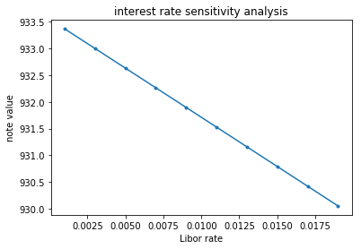

```python
plt.plot(rr, r_sensitivity_analysis, marker='.')
plt.xlabel("Libor rate")
plt.ylabel("note value")
plt.title("interest rate sensitivity analysis")
plt.show()
```

### We check the note value when Libor rate is from 0.1% to 1.9% and find the relationship is linearly negative. The value changes so small, just from about 933.5 decreasing to 930.

```python
siggma = [i/1000 for i in range(300,600,15)]
sigma_sensitivity_analysis = []

for s in siggma:
    b = lu(s0,su,sl,T,q,0.005131,s,k,jmax,imax)
    sigma_sensitivity_analysis.append(b)
```

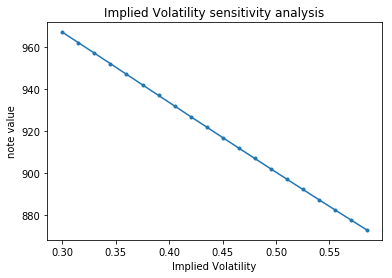

```python
plt.plot(siggma, sigma_sensitivity_analysis, marker='.')
plt.xlabel("Implied Volatility")
plt.ylabel("note value")
plt.title("Implied Volatility sensitivity analysis")
plt.show()
```

### We check the note value when Implied Volatility is from 30% to 58.5% and find the relationship is linearly negative. However, compared with the range of value under Libor rate changing, the value changes is relatively large. When volatility is higher, the value will lower than 880.

```python
jmax_sensitivity_analysis =[]
for j in [180,240,360,420,480,540]:
    c = lu(s0,su,sl,T,q,r,sigma,k,j,imax)
    jmax_sensitivity_analysis.append(c)
```

```python
jmaxx=[180,240,360,420,480,540]
```

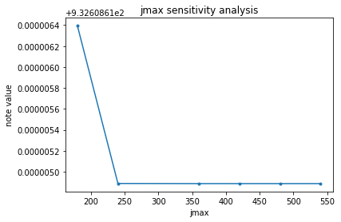

```python
plt.plot(jmaxx,jmax_sensitivity_analysis, marker='.')
plt.xlabel("jmax")
plt.ylabel("note value")
plt.title("jmax sensitivity analysis")
plt.show()
```

```python
jmax_sensitivity_analysis
```

```
[932.6086163939158,
 932.6086148879244,
 932.6086148865393,
 932.6086148865393,
 932.6086148865393,
 932.6086148865393]
```

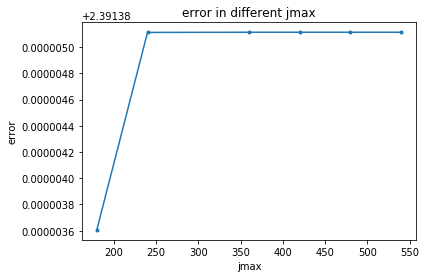

```python
error_jmax = amazon-np.array(jmax_sensitivity_analysis)
plt.plot(jmaxx,error_jmax, marker='.')
plt.xlabel("jmax")
plt.ylabel("error")
plt.title("error in different jmax")
plt.show()
```

### The gap is so small as the vertical axis shows. Therefore, the model is not sensitive to jmax choice. As for imax, because of the unconditional stability, we do not need to check it. The value should be stable no matter how we choose imax.

## Conclusion

### The note value is around 932.61 and the error is about 2.39.

### In sensitivity analysis, we can see the stability of the model. The model is not sensitive to Libor rate but super sensitive to changes in Implied Volatility.

### The advantage of the model is stable and all the value in each point can be calculated. LU decomposition allows us to solve the matrix equation without having to invert it. More importantly, the method avoid nonlinearity error.

### However, unaccuracy of model is mainly come from the discontinuity of second derivative at autocall level. and the LU method does not perform particular well for exotic options, perhaps SOR method is better. Addtionally, in our code, there are some approximations when to decide review date as i in review date is not interger so we round it, which may cause unaccuracy as well.